# Time Series Analysis of Out-of-Service Buses

UW DSSG Paratransit Group

updated: Monday 31st August 2015

# Time Series Analysis

In the following analyses, we analyze the daily percentage of out-of-service buses for King County Metro (KCM). Buses become out-of-service generally after breaking down or if they are unable to arrive at their destinations. Predicting out-of-service buses is important from an operational perspective because KCM and their contractors can better manage their vehicle fleet by preparing adequate standby vehicles each day.

Our model uses the daily percentage of out-of-service buses relative to all buses operating that day (instead of raw counts of out-of-service buses). Using time series techniques, we analyzed almost 18 months (January 2014 to May 2015) of KCM transit data and concluded:

- On average, 7.47% of buses are out-of-service each day
- No deterministic trend over time
- Some weekly seasonal variation
- A snowstorm on February 9th 2014 coincided with the highest daily percentage of out-of service buses
- Out-of-service bus percentages are likely stationary
- Cross validation comparisons between ARMA models indicate an AR(1)MA(2) may be the best model to forecast future daily percentages of out-of-service buses

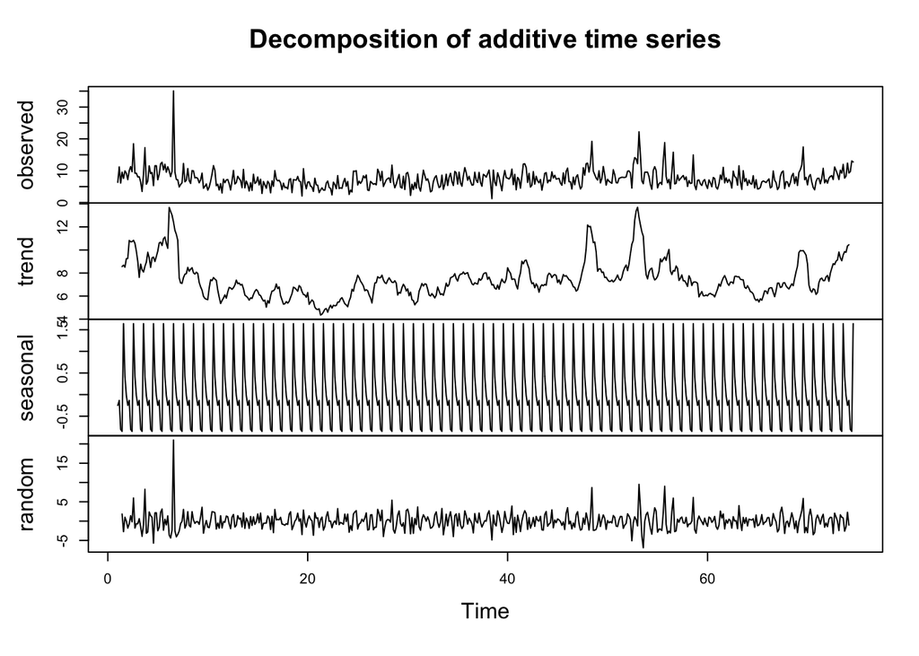

```r
# Plot - Time Series Decomposition
#png(filename = "Plot - Time Series Decomposition.png")
#ts.pctCode8.detrend<-ts(ts.pctCode8.detrend, frequency = 7)
ts.pctCode8.decomposition <- decompose(ts.pctCode8,type="additive")
plot(ts.pctCode8.decomposition)
```

```r
#dev.off()
par(mfrow=c(1,1))

# data has some seasonalilty
# removing seasonal trend from percentage of out service buses
ts.pctCode8.deseasonalized<-ts.pctCode8-ts.pctCode8.decomposition$seasonal
meanCode8Deaseasonalized<-summary(ts.pctCode8.deseasonalized)[4]
meanCode8
```

```
##  Mean
## 7.466
```

```r
meanCode8Deaseasonalized
```

```
##  Mean
## 7.467
```

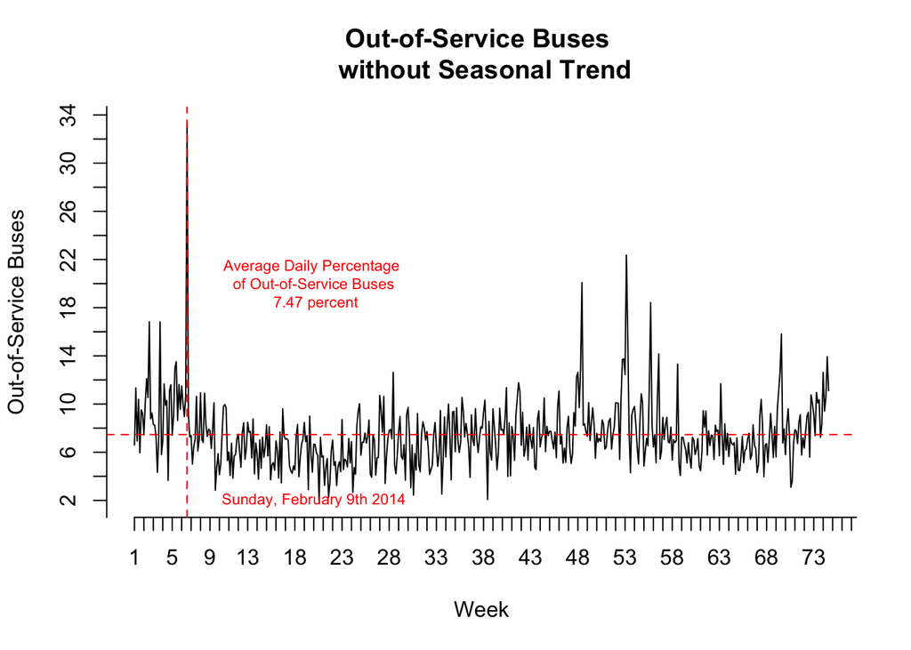

```r
# Plot - Out-of-Service Time Series (Deseasonal)
#png(filename = "Plot - Out-of-Service Time Series (Deseasonal).png")
plot(ts.pctCode8.deseasonalized,type="l",col="black",ylab="Out-of-Service Buses",xlab="Week", axes =FALSE, main = "Out-of-Service Buses \n without Seasonal Trend")
axis(1,1:80)
axis(2,seq(0,36,2))
text(sprintf("Average Daily Percentage \n of Out-of-Service Buses \n %.02f percent", meanCode8),x = 20, y = 20, col="red",cex=0.7)
abline(a=meanCode8Deaseasonalized,b=0, col = 'red',lty="dashed") # comparison line
abline(v=6.56,col = 'red',lty="dashed") # comparison line
text("Sunday, February 9th 2014", x = 20, y = 2, col="red",cex=0.7 )
```

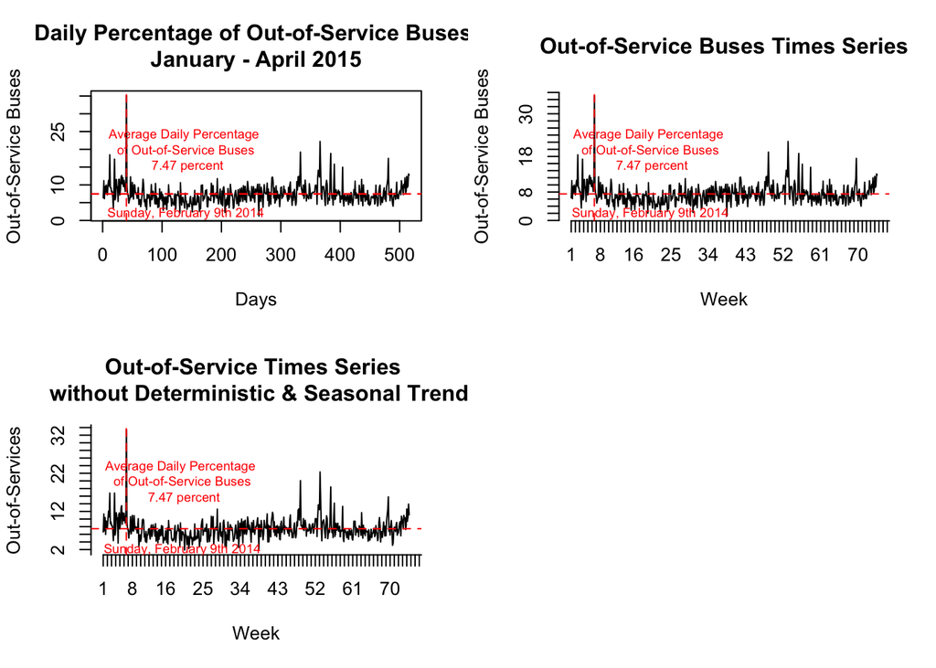

```r
#dev.off()
# no real improvement without seasonal trend

# Plots - Comparing Out-of-Service Time Series
#png(filename = "Plot - Comparing Out-of-Service Time Series.png")
par(mfrow=c(2,2))
plot(pctCode8 ,type="l",ylab="Out-of-Service Buses",xlab="Days",
     main = "Daily Percentage of Out-of-Service Buses \n January - April 2015 ", axes = TRUE)
abline(a=meanCode8,b=0, col = 'red',lty="dashed") # comparison line
text(sprintf("Average Daily Percentage \n of Out-of-Service Buses \n %.02f percent", meanCode8),x = 140, y = 20, col="red",cex=0.7)
abline(a=meanCode8,b=0, col = 'red',lty="dashed") # comparison line
abline(v=40,col = 'red',lty="dashed") # comparison line
text("Sunday, February 9th 2014", x = 140, y = 2, col="red",cex=0.7 )

plot(ts.pctCode8,type="l",col="black",ylab="Out-of-Service Buses",xlab="Week", axes =FALSE, main = "Out-of-Service Buses Times Series")
axis(1,1:80)
axis(2,seq(0,36,2))
text(sprintf("Average Daily Percentage \n of Out-of-Service Buses \n %.02f percent", meanCode8),x = 20, y = 20, col="red",cex=0.7)
abline(a=meanCode8,b=0, col = 'red',lty="dashed") # comparison line
abline(v=6.56,col = 'red',lty="dashed") # comparison line
text("Sunday, February 9th 2014", x = 20, y = 2, col="red",cex=0.7 )

#png(filename = "Plot - Comparing Out-of-Service Time Series.png")
#par(mfrow=c(2,1))
#par(mar = rep(2, 4))
#plot(ts.pctCode8.detrend,type="l", col="black",ylab="Out-of-Service Buses",xlab="Week", main = "Out-of-Service Times Series \n without Deterministic Trend", axes =FALSE)
#axis(1,1:80)
#axis(2,seq(0,.36,.02))
#abline(a=meanCode8,b=0, col = 'red',lty="dashed") # comparison line

# Plot - Out-of-Service Times Series without Deterministic & Seasonal Trend
plot(ts.pctCode8.deseasonalized,type="l",col="black",ylab="Out-of-Services",xlab="Week", axes =FALSE, main = "Out-of-Service Times Series \n without Deterministic & Seasonal Trend")
axis(1,1:80)
axis(2,seq(0,36,2))
text(sprintf("Average Daily Percentage \n of Out-of-Service Buses \n %.02f percent", meanCode8),x = 20, y = 20, col="red",cex=0.7)
abline(a=meanCode8Deaseasonalized,b=0, col = 'red',lty="dashed") # comparison line
abline(v=6.56,col = 'red',lty="dashed") # comparison line
text("Sunday, February 9th 2014", x = 20, y = 2, col="red",cex=0.7 )

#dev.off()

# check for autoregressive (AR) process
#png(filename = "ACF and PACF plots.png")
par(mfrow=c(2,2))
```

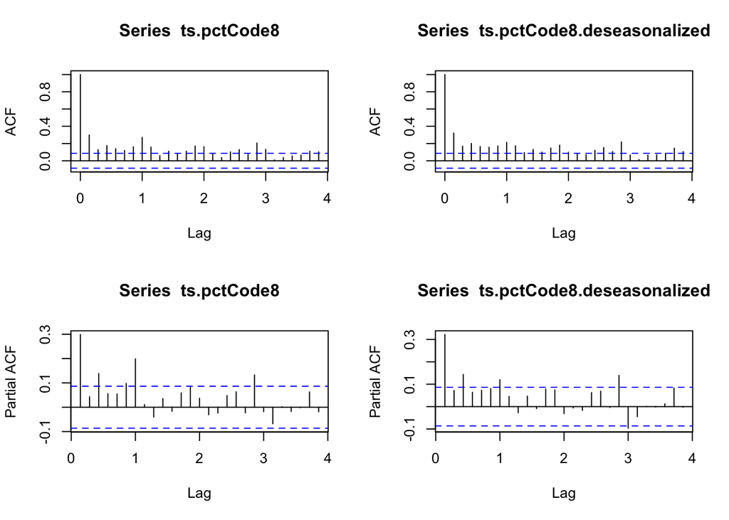

```r
acf(ts.pctCode8)
acf(ts.pctCode8.deseasonalized)

pacf(ts.pctCode8)
pacf(ts.pctCode8.deseasonalized)
```

```r
#dev.off()
par(mfrow=c(1,1))

# Estimate of AR parameters
ar(ts.pctCode8)
```

```
##
## Call:
## ar(x = ts.pctCode8)
##
## Coefficients:
##       1        2        3        4        5        6        7
##  0.2445  -0.0130   0.1025   0.0188   0.0299   0.0451   0.1989
##
## Order selected 7  sigma^2 estimated as  7.181
```

```r
ar(ts.pctCode8.deseasonalized)
```

```
##
## Call:
## ar(x = ts.pctCode8.deseasonalized)
##
## Coefficients:
##       1        2        3        4        5        6        7        8
##  0.2644  -0.0043   0.1053   0.0331   0.0179   0.0420   0.0833   0.0494
##       9       10       11       12       13       14       15       16
## -0.0361   0.0251  -0.0255   0.0454   0.0716  -0.0345  -0.0078  -0.0343
##      17       18       19       20       21
##  0.0333   0.0780  -0.0388   0.1634  -0.0964
##
## Order selected 21  sigma^2 estimated as  6.5
```

```r
# Unit root tests for stationarity
PP.test(ts.pctCode8)
```

```
##
##  Phillips-Perron Unit Root Test
##
## data:  ts.pctCode8
## Dickey-Fuller = -17.164, Truncation lag parameter = 6, p-value =
## 0.01
```

```r
adf.test(ts.pctCode8)
```

```
##
##  Augmented Dickey-Fuller Test
##
## data:  ts.pctCode8
## Dickey-Fuller = -4.7015, Lag order = 8, p-value = 0.01
## alternative hypothesis: stationary
```

```r
PP.test(ts.pctCode8.deseasonalized)
```

```
##
##  Phillips-Perron Unit Root Test
##
## data:  ts.pctCode8.deseasonalized
## Dickey-Fuller = -16.929, Truncation lag parameter = 6, p-value =
## 0.01
```

```r
adf.test(ts.pctCode8.deseasonalized)
```

```
##
##  Augmented Dickey-Fuller Test
##
## data:  ts.pctCode8.deseasonalized
## Dickey-Fuller = -4.7093, Lag order = 8, p-value = 0.01
## alternative hypothesis: stationary
```

```r
# Unit root test p-values
PP.count.pvalues <- try(PP.test(ts.pctCode8)$p.value) #Find the PP test p-value
adf.count.pvalues <- try(adf.test(ts.pctCode8)$p.value)  #Find adf test p-value
PP.count.pvalues
```

```
## [1] 0.01
```

```r
adf.count.pvalues
```

```
## [1] 0.01
```

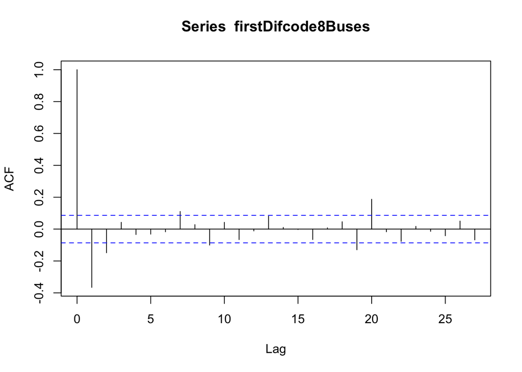

```r
# ADF/PP test null hypothesis is non-stationarity
# Unit root tests indicate stationarity

# If non-stationary, use first difference of out-of-service counts and re-run unit root tests
firstDifcode8Buses <- ts(ts.pctCode8.deseasonalized-as.vector(Lag(pctCode8 ,k=1)))
acf(firstDifcode8Buses,na.action=na.pass)
```

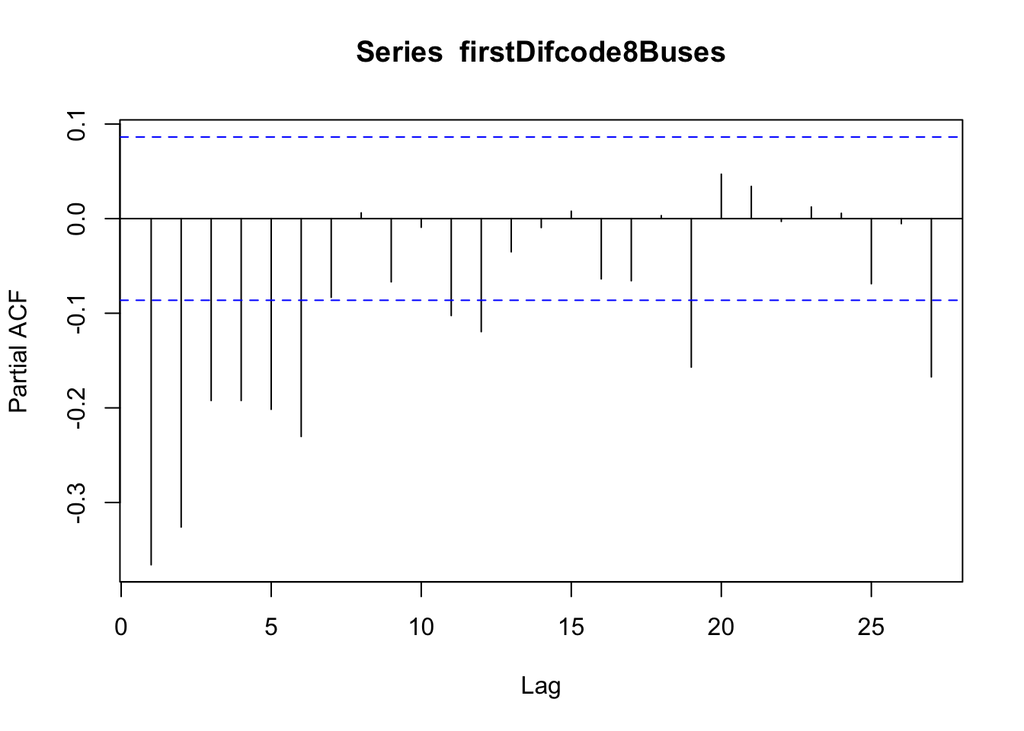

```r
pacf(firstDifcode8Buses,na.action=na.pass)
```

```r
#adf.test(firstDifcode8Buses[-1])
#PP.test(firstDifcode8Buses[-1])
```

```r
# use auto arima to estimate best arima model
# auto arima suggests AR1I1MA2 or AR2MA2
auto.arima(ts.pctCode8)
```

```
## Series: ts.pctCode8
## ARIMA(1,1,1)(1,0,2)[7]
##
## Coefficients:
##          ar1      ma1     sar1    sma1    sma2
##       0.1816  -0.9513  -0.7014  0.8748  0.1892
## s.e.  0.0468   0.0154   0.1651  0.1658  0.0502
##
## sigma^2 estimated as 7.113:  log likelihood=-1234.52
## AIC=2481.05   AICc=2481.21   BIC=2506.51
```

```r
# initial model of choice
## Estimate an AR(1), I(1) MA(2) using arima
arima.ar1i1ma2.pctCode8 <- arima(ts.pctCode8, order = c(1,1,2),
                               include.mean = TRUE)

# comparison models
# Estimate an AR(2), I(1) MA(2) using arima
arima.ar2i1ma2.pctCode8 <- arima(ts.pctCode8, order = c(2,1,2),
                                include.mean = TRUE
)

# Estimate an AR(1), I(1) MA(1) using arima
arima.ar1i1ma1.pctCode8 <- arima(ts.pctCode8, order = c(1,1,1),
                               include.mean = TRUE
)

# Estimate an AR(2), I(1) MA(1) using arima
arima.ar2i1ma1.pctCode8 <- arima(ts.pctCode8, order = c(2,1,1),
                               include.mean = TRUE
)

# Estimate an AR(1)MA(2) using arima
arima.ar1i0ma2.pctCode8 <- arima(ts.pctCode8, order = c(1,0,2),
                               include.mean = TRUE)
# Estimate an AR(2)MA(1) using arima
arima.ar2i0ma1.pctCode8 <- arima(ts.pctCode8, order = c(2,0,1),
                               include.mean = TRUE)

# initial model of choice
# Estimate an AR(2)MA(2) using arima
arima.ar2i0ma2.pctCode8 <- arima(ts.pctCode8, order = c(2,0,2),
                               include.mean = TRUE
)

# Extract goodness of fit results from arima models
se.ar1i1ma2.pctCode8 <- arima.ar1i1ma2.pctCode8$sigma2    # standard error of the regression
aic.ar1i1ma2.pctCode8 <- arima.ar1i1ma2.pctCode8$aic      # Akaike Information Criterion
se.ar2i1ma2.pctCode8 <- arima.ar1i1ma2.pctCode8$sigma2    # standard error of the regression
aic.ar2i1ma2.pctCode8 <- arima.ar1i1ma2.pctCode8$aic      # Akaike Information Criterion
se.ar1i1ma1.pctCode8 <- arima.ar1i1ma1.pctCode8$sigma2    # standard error of the regression
aic.ar1i1ma1.pctCode8 <- arima.ar1i1ma1.pctCode8$aic      # Akaike Information Criterion
se.ar2i1ma1.pctCode8 <- arima.ar2i1ma1.pctCode8$sigma2    # standard error of the regression
aic.ar2i1ma1.pctCode8 <- arima.ar2i1ma1.pctCode8$aic      # Akaike Information Criterion
se.arima.ar1i0ma2.pctCode8<- arima.ar1i0ma2.pctCode8$sigma2 # standard error of the regression
aic.arima.ar1i0ma2.pctCode8<- arima.ar1i0ma2.pctCode8$aic # standard error of the regression
se.arima.ar2i0ma1.pctCode8<- arima.ar2i0ma1.pctCode8$sigma2 # standard error of the regression
aic.arima.ar2i0ma1.pctCode8<- arima.ar2i0ma1.pctCode8$aic # standard error of the regression
se.arima.ar2i0ma2.pctCode8<- arima.ar2i0ma2.pctCode8$sigma2 # standard error of the regression
aic.arima.ar2i0ma2.pctCode8<- arima.ar2i0ma2.pctCode8$aic # standard error of the regression

# all standard errors and aic for arima models
all.arima.se.pctCode8<-c(se.ar1i1ma2.pctCode8, se.ar2i1ma2.pctCode8, se.ar1i1ma1.pctCode8,se.ar2i1ma1.pctCode8, se.arima.ar1i0ma2.pctCode8, se.arima.ar2i0ma1.pctCode8, se.arima.ar2i0ma2.pctCode8)
all.arima.aic.pctCode8<-c(aic.ar1i1ma2.pctCode8, aic.ar2i1ma2.pctCode8, aic.ar1i1ma1.pctCode8, aic.ar2i1ma1.pctCode8, aic.arima.ar1i0ma2.pctCode8, aic.arima.ar2i0ma1.pctCode8, aic.arima.ar2i0ma2.pctCode8)


# all standard errors and aic for ARMA models
all.arma.se.pctCode8<-c(se.arima.ar1i0ma2.pctCode8, se.arima.ar2i0ma1.pctCode8, se.arima.ar2i0ma2.pctCode8)
all.arma.aic.pctCode8<-c(aic.arima.ar1i0ma2.pctCode8, aic.arima.ar2i0ma1.pctCode8, aic.arima.ar2i0ma2.pctCode8)
```

```r
# Attempt at rolling window cross-validation
# comparing out-of service prediction accuracy 15 hypothetical periods (weeks) forward
# model of choice
cv.ar1i1ma2.pctCode8 <- arimaCV(x=pctCode8 , order=c(1,1,2), forward=10, method = "ML",
                              xreg = firstDifcode8Buses, include.mean=TRUE, minper=15)

# comparison models
# ar2i1ma2
cv.ar2i1ma2.pctCode8 <- arimaCV(pctCode8 , order=c(2,1,2), forward=10, method = "ML",
                              xreg=firstDifcode8Buses, include.mean=TRUE, minper=15)

# ar1i1ma1
cv.ar1i1ma1.pctCode8 <- arimaCV(pctCode8 , order=c(1,1,1), forward=10, method = "ML",
                              xreg=firstDifcode8Buses, include.mean=TRUE, minper=15)

# ar2i1ma1
cv.ar2i1ma1.pctCode8 <- arimaCV(pctCode8 , order=c(2,1,1), forward=10, method = "ML",
                              xreg=firstDifcode8Buses, include.mean=TRUE, minper=15)

# ar1i1ma1
cv.ar1i0ma2.pctCode8 <- arimaCV(pctCode8 , order=c(1,0,2), forward=10, method = "ML",
                              xreg=firstDifcode8Buses, include.mean=TRUE, minper=15)

# ar2i0ma1
cv.ar2i0ma1.pctCode8 <- arimaCV(pctCode8 , order=c(2,0,1), forward=10, method = "ML",
                              xreg=firstDifcode8Buses, include.mean=TRUE, minper=15)

# model of choice
# ar2i0ma2
cv.ar2i0ma2.pctCode8 <- arimaCV(pctCode8 , order=c(2,0,2), forward=10, method = "ML",
                              xreg=firstDifcode8Buses, include.mean=TRUE, minper=15)

# Plot cross-validation results
# ARIMA and ARMA models
all.arima.cv.pctCode8 <- cbind(cv.ar1i1ma2.pctCode8, cv.ar1i1ma1.pctCode8, cv.ar2i1ma2.pctCode8, cv.ar2i1ma1.pctCode8, cv.ar1i0ma2.pctCode8, cv.ar2i0ma1.pctCode8,cv.ar2i0ma2.pctCode8)
avg.arima.cv.pctCode8<-apply(all.arima.cv.pctCode8, 2, mean)
arima.models <- c("AR1I1MA2", "AR2I1MA2","AR1I1MA1", "AR2I1MA1", "AR1MA2", "AR2MA1", "AR2MA2")
arima.model.comparison.pctCode8<-as.data.frame(cbind(arima.models,round(all.arima.aic.pctCode8,3),round(all.arima.se.pctCode8,3), round(avg.arima.cv.pctCode8,3)))
names(arima.model.comparison.pctCode8)<-c("models","AIC","SE","MAE")
arima.model.comparison.pctCode8
```

```
##                        models      AIC    SE   MAE
## cv.ar1i1ma2.pctCode8 AR1I1MA2 2490.957 7.242 1.813
## cv.ar1i1ma1.pctCode8 AR2I1MA2 2490.957 7.242 2.112
## cv.ar2i1ma2.pctCode8 AR1I1MA1 2492.147 7.287 1.896
## cv.ar2i1ma1.pctCode8 AR2I1MA1 2491.989 7.257 2.019
## cv.ar1i0ma2.pctCode8   AR1MA2 2493.909 7.206  1.74
## cv.ar2i0ma1.pctCode8   AR2MA1 2495.645  7.23 1.762
## cv.ar2i0ma2.pctCode8   AR2MA2 2494.136 7.181  1.81
```

```r
# ARMA models only
all.arma.cv.pctCode8 <- cbind(cv.ar1i0ma2.pctCode8, cv.ar2i0ma1.pctCode8,cv.ar2i0ma2.pctCode8)
avg.arma.cv.pctCode8<-apply(all.arma.cv.pctCode8, 2, mean)
arma.models <- c("AR1MA2", "AR2MA1", "AR2MA2")
arma.model.comparison.pctCode8<-as.data.frame(cbind(arma.models,round(all.arma.aic.pctCode8,3),round(all.arma.se.pctCode8,3), round(avg.arma.cv.pctCode8,3)))
names(arma.model.comparison.pctCode8)<-c("models","AIC","SE","MAE")
arma.model.comparison.pctCode8
```

```
##                      models      AIC    SE   MAE
## cv.ar1i0ma2.pctCode8 AR1MA2 2493.909 7.206  1.74
## cv.ar2i0ma1.pctCode8 AR2MA1 2495.645  7.23 1.762
## cv.ar2i0ma2.pctCode8 AR2MA2 2494.136 7.181  1.81
```

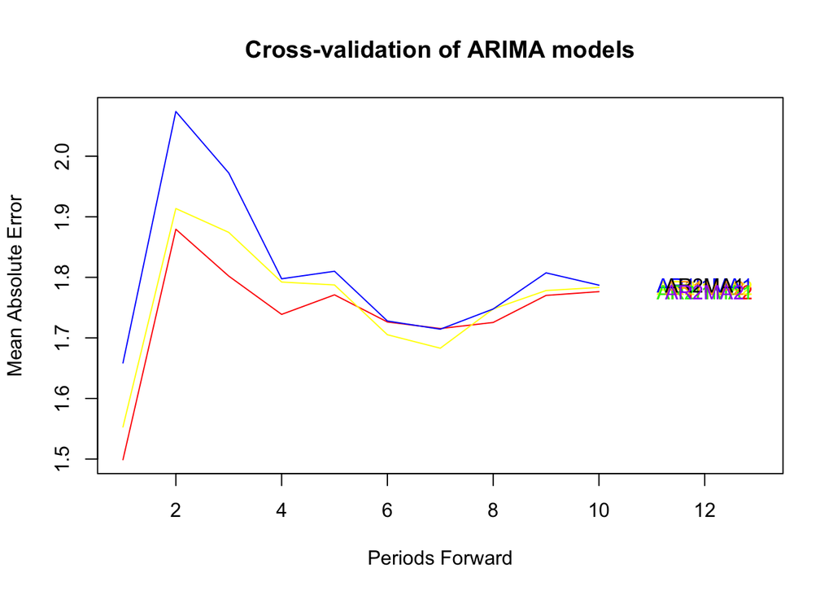

```r
col1 <- c("Red", "Yellow", "Blue", "Green", "Orange", "Black", "Purple", "Brown", "Gold", "Gray")
col2 <- c("Blue", "Orange", "Black")

# Plot - ARIMA Cross Validation
#png(filename = "Plot - ARIMA Cross-Validation.png")
matplot(all.arma.cv.pctCode8, type="l", col=col1, lty=1, ylab="Mean Absolute Error", xlab="Periods Forward", main="Cross-validation of ARIMA models", xlim=c(1,13))
text(arima.models, x=rep(12,length(arima.models)), y=all.arma.cv.pctCode8[nrow(all.arma.cv.pctCode8),], col=col1)
```

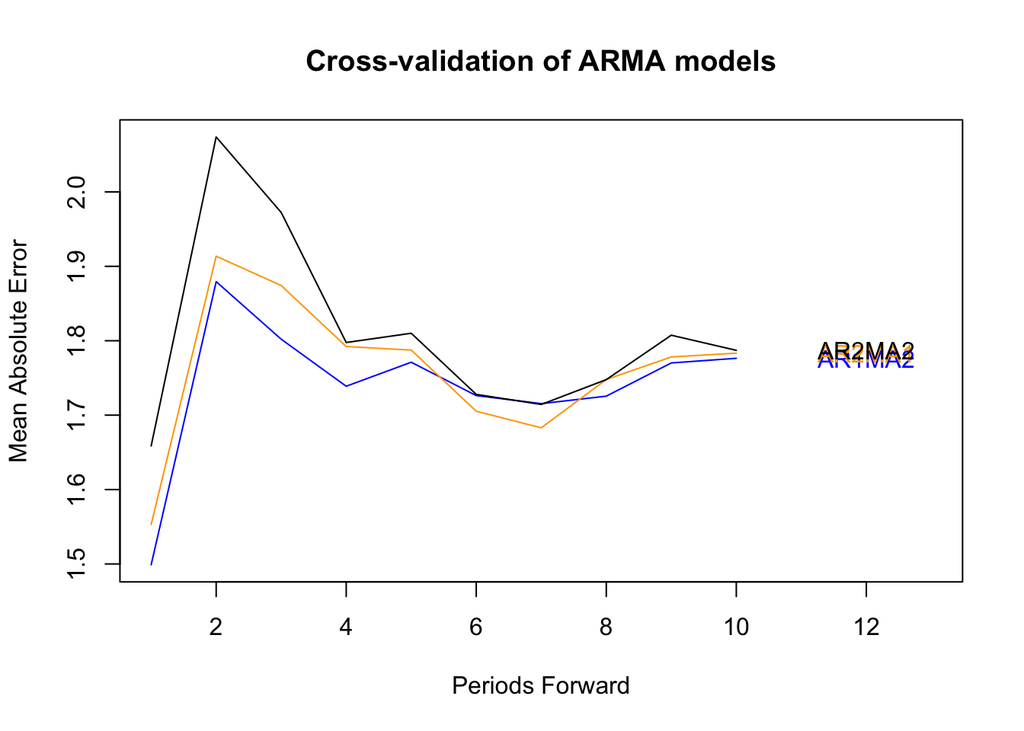

```r
#dev.off()

# Plot - ARMA Cross Validation
#png(filename = "Plot - ARMA Cross-Validation.png")
matplot(all.arma.cv.pctCode8, type="l", col=col2, lty=1, ylab="Mean Absolute Error", xlab="Periods Forward", main="Cross-validation of ARMA models", xlim=c(1,13))
text(arma.models, x=rep(12,length(arma.models)), y=all.arma.cv.pctCode8[nrow(all.arma.cv.pctCode8),], col=col2)
```

```r
#dev.off()

# ar1ma2 is best model
# best combination of lowest AIC and MAE
# final model
arma.final.model.pctCode8 <- arima.ar1i0ma2.pctCode8
```